# Areas and Bounding Boxes

## Polygon Area

`polygon_area` computes the area of a polygon on the ellipsoid in square meters. The polygon is defined by an ordered sequence of vertices and is implicitly closed (the last vertex connects back to the first).

The algorithm uses the **spherical excess** method on the **authalic (equal-area) sphere** – a sphere with the same surface area as the ellipsoid.

```julia
# 1 deg x 1 deg square at the equator
square = [LLA(0, 0), LLA(1, 0), LLA(1, 1), LLA(0, 1)]
area = polygon_area(square)
println("Area: $(round(area / 1e6, digits=0)) km^2")
```

```
Area: 12364.0 km^2
```

```julia
# A larger triangle
triangle = [LLA(-10, 0), LLA(10, 0), LLA(0, 15)]
area = polygon_area(triangle)
println("Area: $(round(area / 1e6, digits=0)) km^2")
```

```
Area: 1.833537e6 km^2
```

Vertex order matters for the sign of the spherical excess, but `polygon_area` returns the absolute value, so either winding order gives the same result:

```julia
polygon_area(reverse(square)) == polygon_area(square)
```

```
true
```

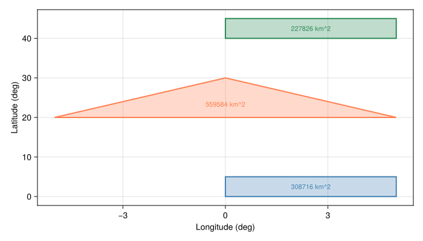

Figure 5.1: Three polygons with their computed areas. Polygon area varies with latitude even for the same angular extent.

```julia
polygons = [
    ("Equatorial square", [LLA(0, 0), LLA(5, 0), LLA(5, 5), LLA(0, 5)]),
    ("Mid-latitude square", [LLA(0, 40), LLA(5, 40), LLA(5, 45), LLA(0, 45)]),
    ("Triangle", [LLA(-5, 20), LLA(5, 20), LLA(0, 30)]),
]
colors = [:steelblue, :seagreen, :coral]

fig = Figure(size=(700, 400))
ax = Axis(fig[1, 1], xlabel="Longitude (deg)", ylabel="Latitude (deg)")
for (i, (label, verts)) in enumerate(polygons)
    lons = [v.lon for v in verts]
    lats = [v.lat for v in verts]
    # Close the polygon for plotting
    push!(lons, lons[1])
    push!(lats, lats[1])

    poly!(ax, Point2f.(lons, lats), color=(colors[i], 0.3), strokecolor=colors[i], strokewidth=2)

    area_km2 = round(polygon_area(verts) / 1e6, digits=0)
    cx = sum(v.lon for v in verts) / length(verts)
    cy = sum(v.lat for v in verts) / length(verts)
    text!(ax, cx, cy; text="$(Int(area_km2)) km^2", fontsize=11, align=(:center, :center), color=colors[i])
end
fig
```

Notice that the mid-latitude square has a smaller area than the equatorial square of the same angular extent – this reflects the convergence of meridians at higher latitudes.

## Bounding Boxes

A `BoundingBox` is an axis-aligned rectangle in longitude/latitude space:

```julia
bb = BoundingBox(-75.0, 40.0, -73.0, 41.0)
```

```
BoundingBox(lon=[-75.0, -73.0], lat=[40.0, 41.0])
```

### From Points

`boundingbox` computes the smallest bounding box containing a set of points:

```julia
pts = [LLA(-74.0, 40.0), LLA(-73.5, 40.8), LLA(-74.5, 40.3), LLA(-73.2, 40.5)]
bb = boundingbox(pts)
```

```
BoundingBox(lon=[-74.5, -73.2], lat=[40.0, 40.8])
```

### Containment

Test whether a point lies within a bounding box:

```julia
in(LLA(-74.0, 40.5), bb)
```

```
true
```

```julia
in(LLA(-72.0, 40.5), bb)
```

```
false
```

The `in` function handles **antimeridian wrapping** automatically. If `min_lon > max_lon`, the box is assumed to wrap across the antimeridian.

### Destination Bounding Box

`destination_boundingbox` computes the bounding box of all points within a given distance from an origin. This is useful for spatial queries (“find all records within 50 km”):

```julia
destination_boundingbox(LLA(-74.006, 40.7128), 50_000.0)
```

```
BoundingBox(lon=[-74.59771173143642, -73.41428826856358], lat=[40.26252811430199, 41.16303665323765])
```

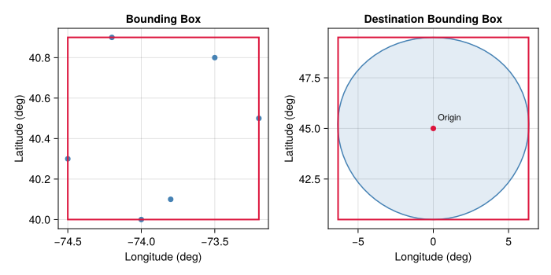

Figure 5.2: A bounding box around scattered points (left) and a destination bounding box showing the area within 500 km of a central point (right).

```julia
fig = Figure(size=(700, 350))

# Left: bounding box from points
pts = [
    LLA(-74.0, 40.0), LLA(-73.5, 40.8), LLA(-74.5, 40.3),
    LLA(-73.2, 40.5), LLA(-74.2, 40.9), LLA(-73.8, 40.1),
]
bb = boundingbox(pts)
ax1 = Axis(fig[1, 1], xlabel="Longitude (deg)", ylabel="Latitude (deg)", title="Bounding Box")
scatter!(ax1, [p.lon for p in pts], [p.lat for p in pts], color=:steelblue, markersize=10)
box_lons = [bb.min_lon, bb.max_lon, bb.max_lon, bb.min_lon, bb.min_lon]
box_lats = [bb.min_lat, bb.min_lat, bb.max_lat, bb.max_lat, bb.min_lat]
lines!(ax1, box_lons, box_lats, color=:crimson, linewidth=2)

# Right: destination bounding box
origin = LLA(0.0, 45.0)
dist = 500_000.0
dbb = destination_boundingbox(origin, dist)
ax2 = Axis(fig[1, 2], xlabel="Longitude (deg)", ylabel="Latitude (deg)", title="Destination Bounding Box")

# Draw the "circle" of destinations
ring = [forward_geodesic(origin, Float64(az), dist) for az in 0:5:360]
poly!(ax2, Point2f.([p.lon for p in ring], [p.lat for p in ring]),
    color=(:steelblue, 0.15), strokecolor=:steelblue, strokewidth=1.5)

# Draw the bounding box
dbox_lons = [dbb.min_lon, dbb.max_lon, dbb.max_lon, dbb.min_lon, dbb.min_lon]
dbox_lats = [dbb.min_lat, dbb.min_lat, dbb.max_lat, dbb.max_lat, dbb.min_lat]
lines!(ax2, dbox_lons, dbox_lats, color=:crimson, linewidth=2)
scatter!(ax2, [origin.lon], [origin.lat], color=:crimson, markersize=10)
text!(ax2, origin.lon + 0.3, origin.lat + 0.3; text="Origin", fontsize=11, align=(:left, :bottom))

fig
```

### Accepts Any AbstractFixedCoords

All functions accept any `AbstractFixedCoords` type, not just `LLA`. ECEF and UTM coordinates are converted automatically:

```julia
ecef_pts = [ECEF(p, WGS84) for p in pts]
boundingbox(ecef_pts)
```

```
BoundingBox(lon=[-74.5, -73.2], lat=[40.00000000000001, 40.9])
```